# did

```r
library(utils)
library(dplyr)
data <- read.csv('did.csv')
data <- data %>%
  mutate( is_ios = as.numeric(is_ios),
          after_update = as.numeric(after_update)
          )
```

Let us denote four averages of the response, as follows:

- $y_{T,A}$: Treatment, After
- $y_{T,B}$: Treatment, Before
- $y_{C,B}$: Control, Before
- $y_{C,A}$: Control, After

The difference-in-differences estimator $\hat\delta$ is defined as below

- $\hat\delta = (y_{T,A}− y_{C,A})−(y_{T,B}−y_{C,B})$
- $Y = \beta_1+\beta_2 T+\beta_3 A+δT×A+\epsilon$

```r
summary(data)
```

```
##    app_name             is_ios     after_update average_revenue_per_dau
##  Length:96          Min.   :0.0   Min.   :0.0   Min.   :0.000e+00
##  Class :character   1st Qu.:0.0   1st Qu.:0.0   1st Qu.:9.338e-05
##  Mode  :character   Median :0.5   Median :0.5   Median :1.473e-04
##                     Mean   :0.5   Mean   :0.5   Mean   :2.406e-04
##                     3rd Qu.:1.0   3rd Qu.:1.0   3rd Qu.:2.592e-04
##                     Max.   :1.0   Max.   :1.0   Max.   :1.973e-03
##   app_download
##  Min.   :    167.4
##  1st Qu.:  27744.0
##  Median :  62477.8
##  Mean   : 117449.9
##  3rd Qu.: 143262.1
##  Max.   :1069524.0
```

```r
did_model <- lm( app_download~is_ios*after_update, data=data)
summary(did_model)
```

```
##
## Call:
## lm(formula = app_download ~ is_ios * after_update, data = data)
##
## Residuals:
##     Min      1Q  Median      3Q     Max
## -180915  -65297  -23747   15338  863833
##
## Coefficients:
##                     Estimate Std. Error t value Pr(>|t|)
## (Intercept)           164380      29670   5.540 2.85e-07 ***
## is_ios               -114391      41960  -2.726  0.00767 **
## after_update           41311      41960   0.985  0.32744
## is_ios:after_update   -41561      59340  -0.700  0.48545
## ---
## Signif. codes:  0 '***' 0.001 '**' 0.01 '*' 0.05 '.' 0.1 ' ' 1
##
## Residual standard error: 145400 on 92 degrees of freedom
## Multiple R-squared:  0.191,  Adjusted R-squared:  0.1647
## F-statistic: 7.242 on 3 and 92 DF,  p-value: 0.0002047
```

- $Y = 164380 -114391 T+ 41311 A + -41561T×A+\epsilon$

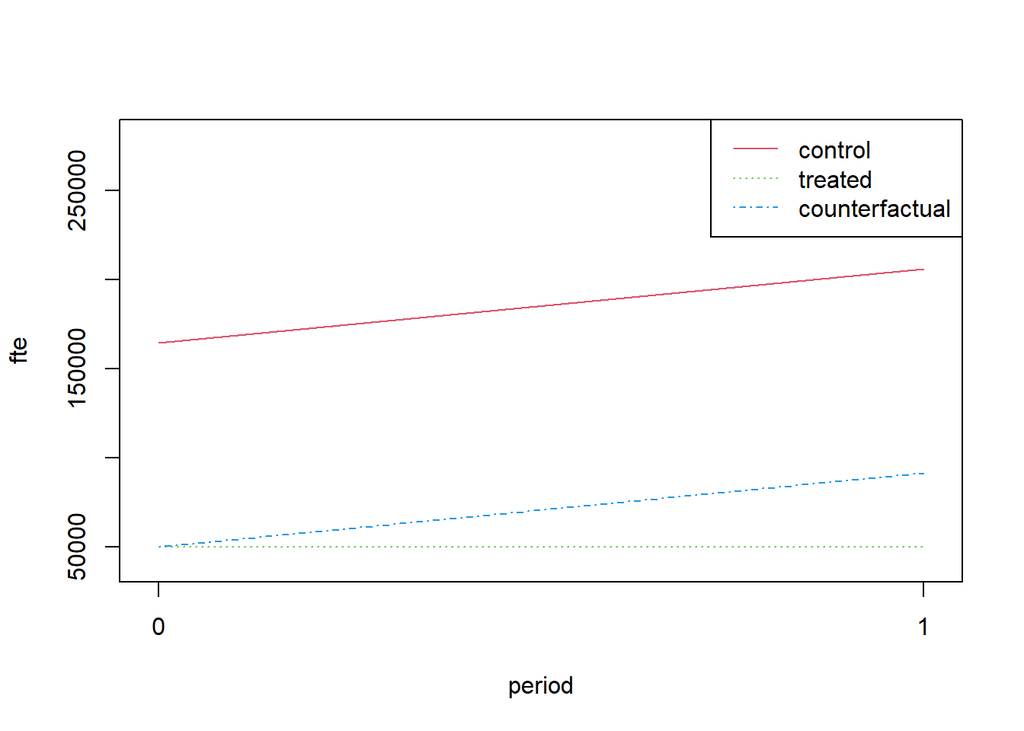

```r
b1 <- coef(did_model)[[1]]
b2 <- coef(did_model)[["is_ios"]]
b3 <- coef(did_model)[["after_update"]]
delta <- coef(did_model)[["is_ios:after_update"]]
C <- b1+b2+b3+delta
E <- b1+b3
B <- b1+b2
A <- b1
D <- E+(B-A)
# This creates an empty plot:
plot(1, type="n", xlab="period", ylab="fte", xaxt="n",
     xlim=c(-0.01, 1.01), ylim=c(40000, 280000))
segments(x0=0, y0=A, x1=1, y1=E, lty=1, col=2)#control
segments(x0=0, y0=B, x1=1, y1=C, lty=3, col=3)#treated
segments(x0=0, y0=B, x1=1, y1=D,      #counterfactual
         lty=4, col=4)
legend("topright", legend=c("control", "treated",
                            "counterfactual"), lty=c(1,3,4), col=c(2,3,4))
axis(side=1, at=c(0,1), labels=NULL)
```

The figure displays the change of app_download from the period before ( after_update=0 ) to the period after ios update ( after_update=1 ) for both the treatment and the control groups. The line labeled “counterfactual” shows how the treatment group would have changed in the absence of the treatment, assuming its change would mirror the change in the control group.

ref: https://bookdown.org/ccolonescu/RPoE4/indvars.html#the-difference-in-differences-estimator